# The (Data) Science Behind Comedy College

Jake Veatch

9/3/2020

# Project Summary

This project was designed to analyze data from Comedy College, an Honors seminar course that teaches the science of comedy, and culminates with each student performing a standup to a live crowd.

These standups were recorded, and I was able to spend a large amount of time watching, and collecting data from these standups. The following document serves to demonstrate the summary of the project size, as well as my most interesting finds.

Everything on this page is dynamically generated. Any addition to the data files could be re-knit into a new document that would then include the added data.

The analysis of this project was done using the R Programming Language. This document is generated using RMarkdown, which allows us to run R code, and embed the outputs into a simgle HTML, PDF, etc. documents. See more at https://rmarkdown.rstudio.com/ .

## Crowd Response - Definition

Crowd response is the single-most important measure in our study. It was a measure of the crowd response to a single joke from a scale of 1 (horrible joke, booing, complete silence) to 10 (extended clapping, laughing, cheering, etc.). This was chosen as a measure as it extracted any personal bias to a joke’s “funniness”. The collection of data was then more objective by simply measuring the reaction of the crowd.

### Total Time of Standups Analyzed (minutes)

```r
totalTime
```

```
## [1] 398.8167
```

### Total Number of Comedians Analyzed

```r
comedianCount
```

```
## [1] 48
```

### Total Number of Semesters Analyzed

```r
semestersCount
```

```
## [1] 4
```

# Jokes

The goal of this section is to explore the jokes in the most generic way. How many jokes are told on average per set? What is the average length of the jokes in minutes?

## Jokes per Set

How many jokes are told per set?

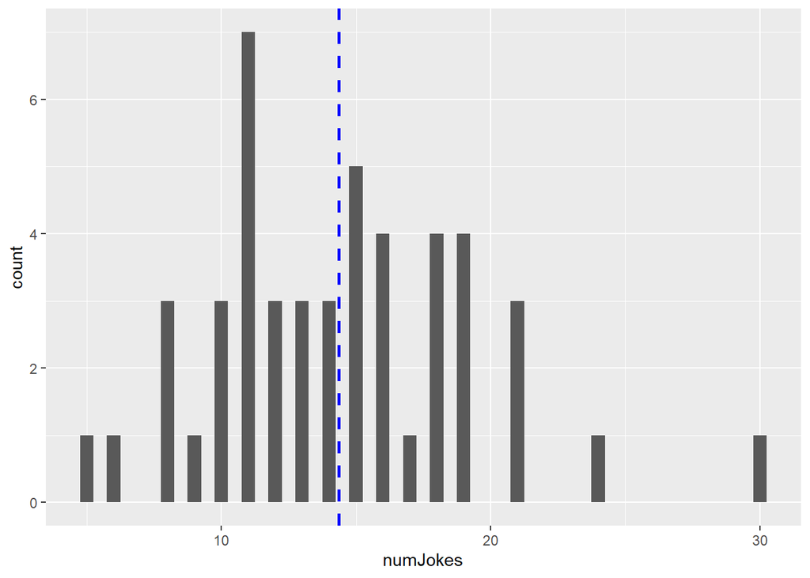

```r
ggplot(setWithNumJokes) +
  geom_histogram(mapping = aes(x = numJokes), binwidth=.5) +
    geom_vline(aes(xintercept=mean(numJokes)), color="blue", linetype="dashed", size=1)
```

The average number of jokes told per set is around 14, with the largest number of comedians telling 11 jokes.

## Average Length of a Joke

What is the average length of a joke told by our comedians (in minutes)?

```r
avgJokeTime
```

```
## [1] 0.4895501
```

## Length of Joke vs Crowd Reaction

How does the length of time for a joke to finish relate to the crowd reaction to that joke?

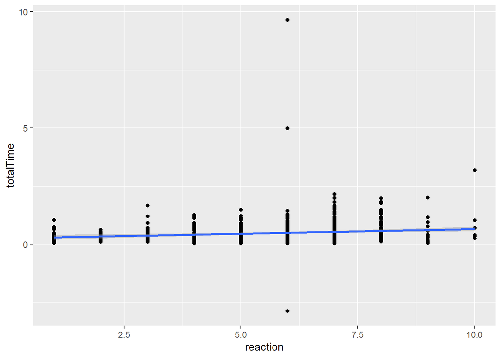

```r
ggplot(jokesWithTimes, aes(x = reaction, y = totalTime)) +
  geom_point() +
  geom_smooth(method = "glm")
```

As we can see, the length of the jokes are not particularly effective in changing the crowds reaction.

# Callbacks

This section focuses on callbacks in a standup. A callback in comedy is when a comedian will relate the joke in some way to a previous joke in the set. Do callbacks get a better crowd reaction than jokes without callbacks? How many jokes apart are callbacks with their original joke? How many times are callbacks used off of the same original joke?

## Callback vs Non-Callback Joke Reactions

How do jokes that use callbacks measure up with the crowd reaction of jokes that do not make callbacks?

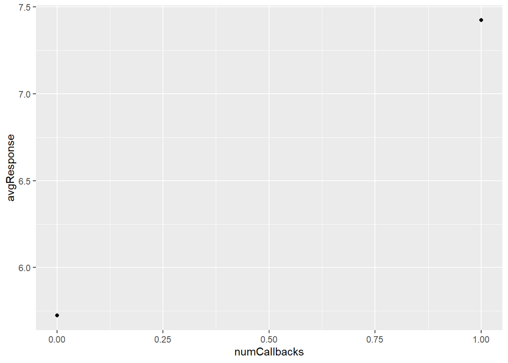

```r
ggplot(avgResponseByNumCallbacks) +
  geom_point(mapping = aes(x = numCallbacks, y = avgResponse))
```

As we can see, the average crowd response for a joke containing one callback is significantly higher than jokes that contain no callbacks at all. Are comedians that use callbacks naturally funnier with crowds? Do crowds like to hear callbacks?

## Callback Separation with Original Joke

How many jokes away are callbacks from their original joke? Overlaid with the average crowd response by that callback distance.

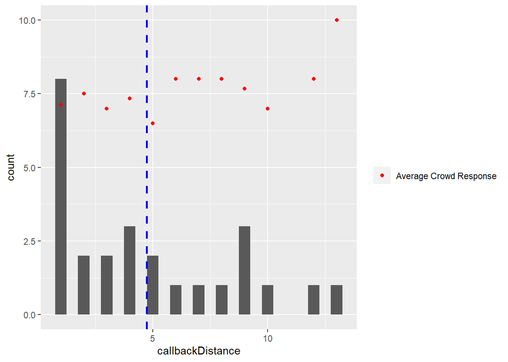

```r
ggplot(distanceCallbackWithResponse) +
  geom_histogram(mapping = aes(x = callbackDistance), binwidth=.5) +
  geom_vline(aes(xintercept=mean(callbackDistance)), color="blue", linetype="dashed", size=1) +
  geom_point(data = avgResponseCallbackDist, aes(x = callbackDistance, y = avgResponse, color = "Average Crowd Response")) +
  scale_color_manual(name = "", breaks = c("Average Crowd Response"), values = c("Average Crowd Response" = "red"))
```

Here we can see that the most used callback distance is actually one joke away. The average callback distance is ~5 jokes away. We can see the overlaid average crowd response performing the best on average with higher distances from the original joke.

## Callback Numbers by Original Joke

How many times are callbacks recycled during a set on a particular root joke?

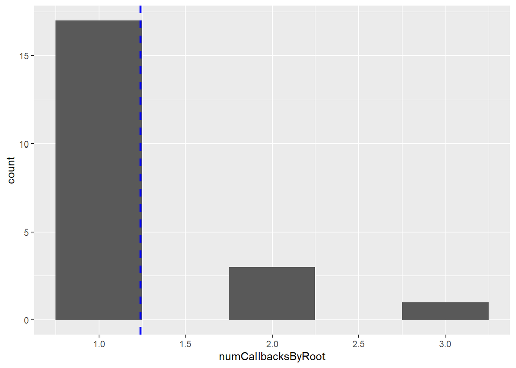

```r
ggplot(numCallbacksByRootJoke) +
  geom_histogram(mapping = aes(x = numCallbacksByRoot), binwidth=.5) +
  geom_vline(aes(xintercept=mean(numCallbacksByRoot)), color="blue", linetype="dashed", size=1)
```

We can observe that overwhelmingly, callbacks are used only once that relate back to an original joke. There are some instances of using the callback up to three times.

# Swearing

The goal of this section is to explore the affect that swearing has on our data. When does swearing occur in sets? Does it tend to occur more often in sooner/later jokes in sets? Does the crowd reaction change based on the presence of swearing in a joke? What swear words are our comedians using? Are there clear favorites?

## Distribution of Swearing in a Set

What is the distribution for the number of times that comedians swore in their sets.?

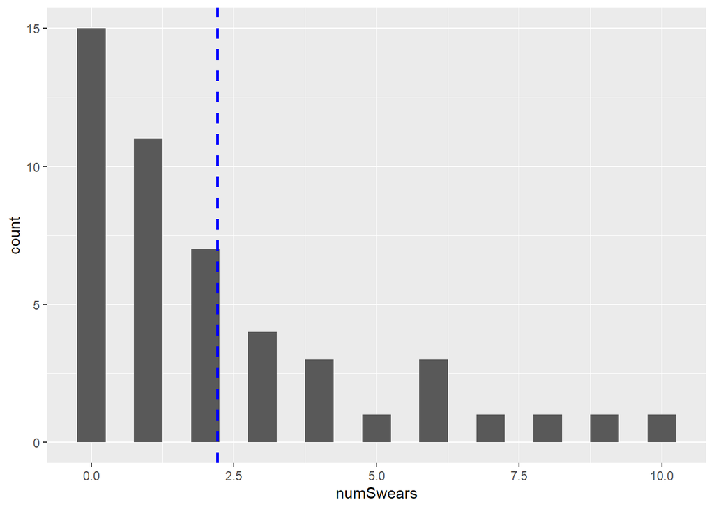

```r
ggplot(comedianAndNumberOfSwearWords) +
  geom_histogram(mapping = aes(x = numSwears), binwidth=.5) +
  geom_vline(aes(xintercept=mean(numSwears)), color="blue", linetype="dashed", size=1)
```

We can see that a large number of comedians used zero swear words, while some comedians went up to ten. The average number is just shy of 2.5 swear words per set.

## Number of Swears vs. Average Crowd Response

How does the crowd response to jokes relate to the total number of swear words in a set?

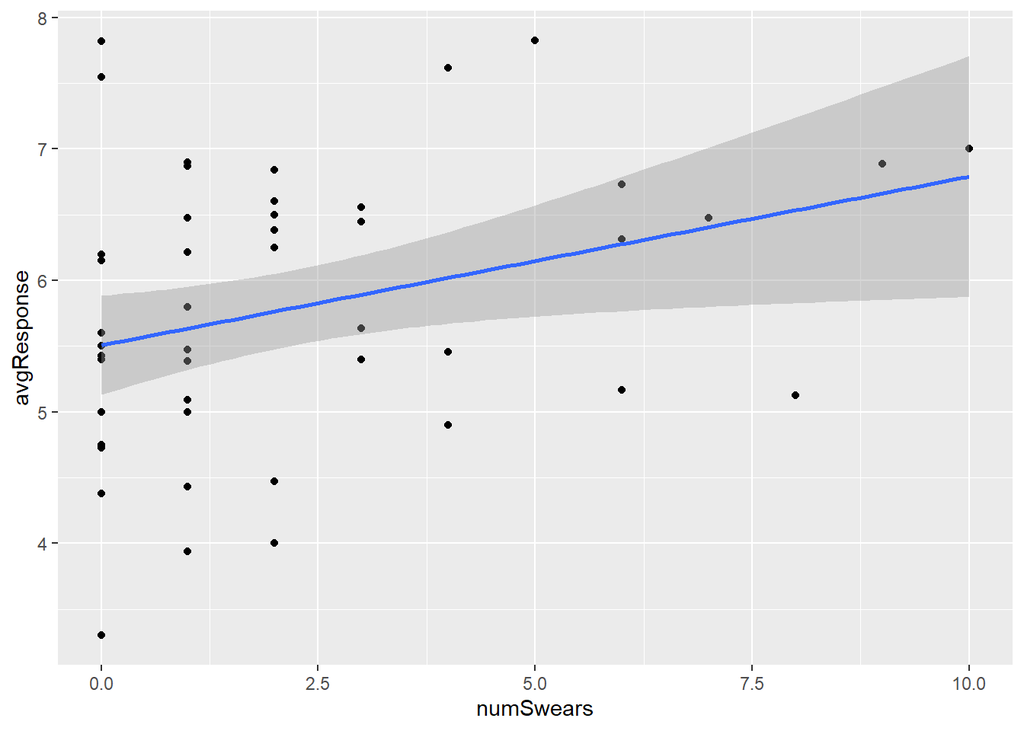

```r
ggplot(comedianAndNumberOfSwearWords, aes(x = numSwears, y = avgResponse)) +
  geom_point() +
  geom_smooth(method = "glm")
```

Interestingly enough, the increase in the number of swear words does indeed increase the average response slightly. The response is an average of ~5.5 with zero swearing and ~6.7 with 10 instances of swearing. We don’t know the exact relation, perhaps comedians that tend to swear feel more comfortable on stage and therefore have better joke delivery skills.

## Number of Swears vs. Average Crowd Response Including Sex

How does the crowd response to jokes relate to the total number of swear words in a set, while separating into male and female groups?

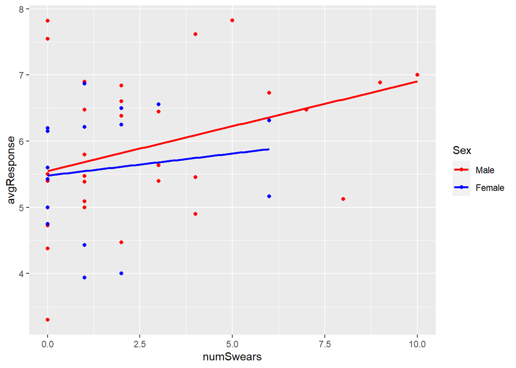

```r
ggplot() +
  geom_point(maleComedianSwears, mapping = aes(x = numSwears, y = avgResponse, color = "Male")) +
  geom_smooth(maleComedianSwears, se = FALSE, mapping = aes(x = numSwears, y = avgResponse, color = "Male"), method = "glm") +
  geom_point(femaleComedianSwears, mapping = aes(x = numSwears, y = avgResponse, color = "Female")) +
  geom_smooth(femaleComedianSwears, se = FALSE, mapping = aes(x = numSwears, y = avgResponse, color = "Female"), method = "glm") +
  scale_color_manual(name = "Sex", breaks = c("Male", "Female"), values = c("Male" = "red", "Female" = "blue"))
```

We can see that the number of swears used is increased in males in our study versus the females. Males went all the way up to ten, while females stopped at six swear words in a set. Male swears also appeared to increase the average crowd response to the set at a larger rate versus their female counterparts.

## Swear Density by Number of Joke in Set

How do swear words spread out through a set? Are they more dense in certain parts such as near the end of the set?

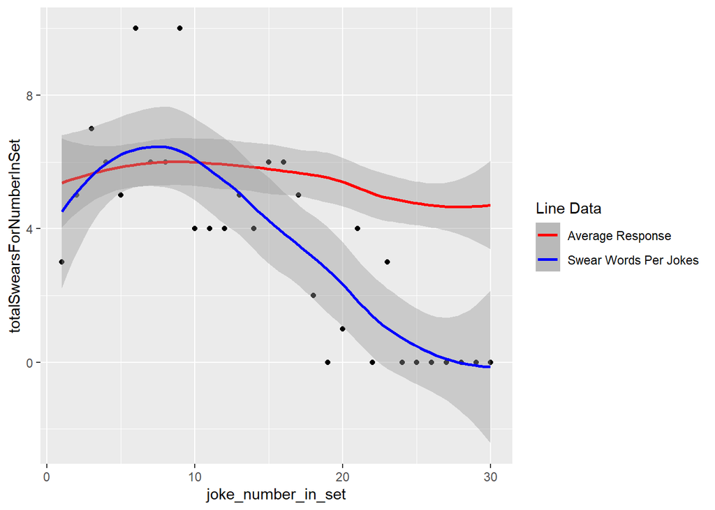

```r
ggplot(swearWordCountByNumberInSet, aes(x = joke_number_in_set, y = totalSwearsForNumberInSet)) +
  geom_point() +
  geom_smooth(method = "loess", mapping = aes(x = joke_number_in_set, y = avgResponse, color = "Average Response")) +
  geom_smooth(method = "loess", aes(color = "Swear Words Per Jokes")) +
  scale_color_manual(name = "Line Data", breaks = c("Average Response", "Swear Words Per Jokes"), values = c("Average Response" = "red", "Swear Words Per Jokes" = "blue"))
```

Based on our data set, we can see that the frequency of swearing actually occurs near the beginning of the set within the first ten jokes and quickly reduces as the number of jokes increases. Perhaps comedians are swearing more frequently due to stress, or to be more informal and personal with the audience.

I also overlay the average response for that number of joke in the set to show how it might be affected by the number of swears for jokes of that order in a set. It stays relatively stable across the differences in swearing.

## Swear Word Choice **Use of Bad Language in This Section**

WATCH YOUR LANGUAGE! What words did our comedians choose to use in their foul jokes?

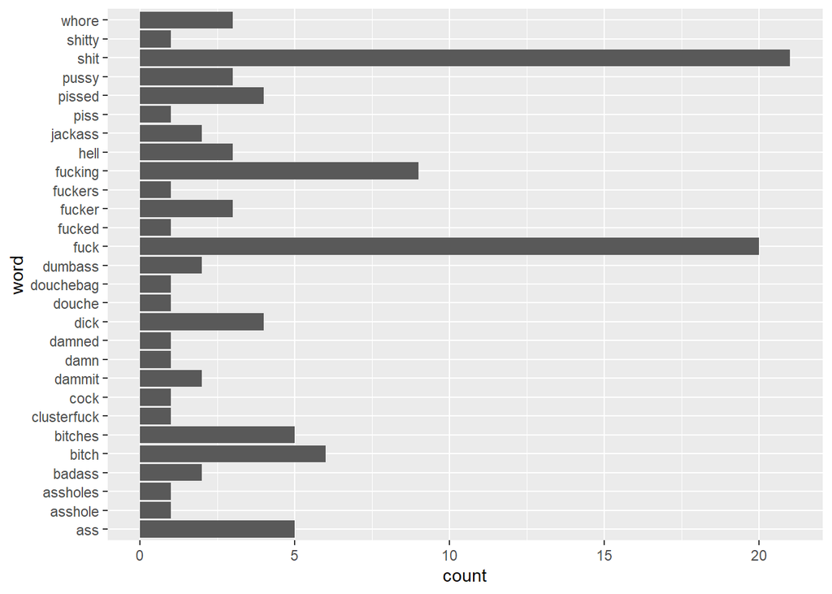

```r
ggplot(swearWords) +
  geom_bar(stat = "identity", mapping = aes(x = word, y = count)) +
  coord_flip()
```

Clearly there are some favorites!

# Demographics

This section involved asking questions such as who was taking the seminar, and did any of their physical characteristics correlate with other measures in their standups. For example did shirt color correlate with the average crowd response to their jokes? Did hair color correlate with the number of swear words used?

## Dominant Hand

How does the dominant hand affect comedy college?

### Dominant Hand vs. Number of Comedians

Are most comedians in the study left or right handed?

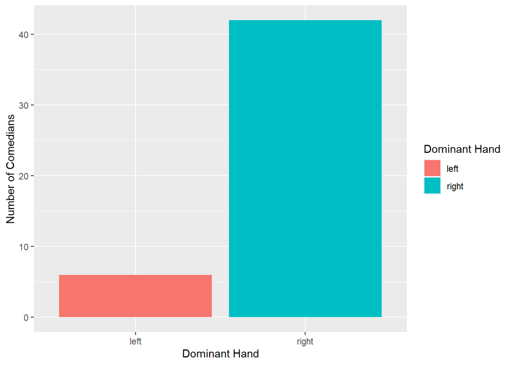

```r
ggplot(comedians) +
  geom_bar(mapping = aes(x = dominant_hand, fill = dominant_hand)) +
  labs(x = "Dominant Hand", fill = "Dominant Hand", y = "Number of Comedians")
```

Here we can see that overwhelmingly, the participants in this study are right-handed.

### Dominant Hand vs. Average Crowd Response

The average crowd response is the measure of the crowds reaction to a joke. It was measured on a scale of 1 to 10 for each joke.

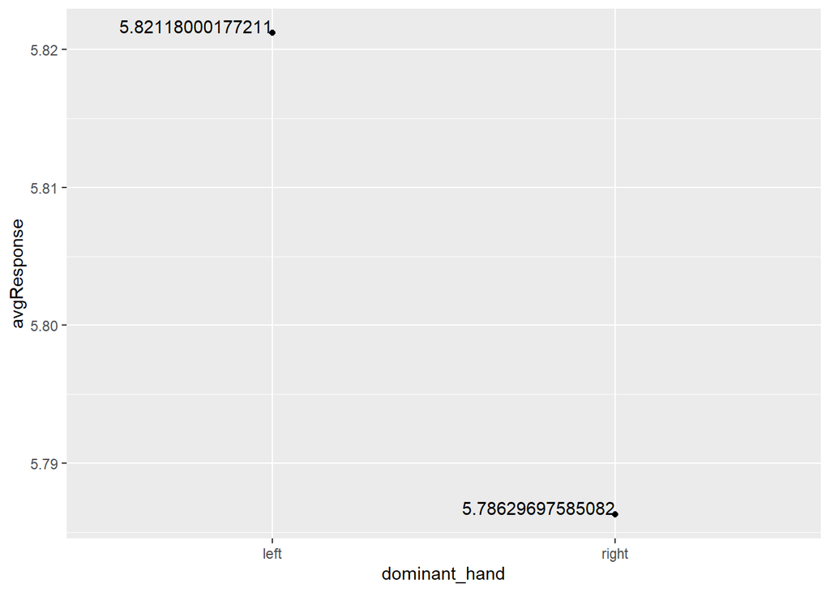

```r
ggplot(dominantHandVsCrowdResp, aes(x = dominant_hand, y = avgResponse)) +
  geom_point() +
  geom_text(aes(label = avgResponse), vjust=0, hjust=1)
```

Clearly, the difference is marginal between lefties and righties.

### Dominant Hand and Number of Jokes

Does handedness affect how many jokes a comedian tells?

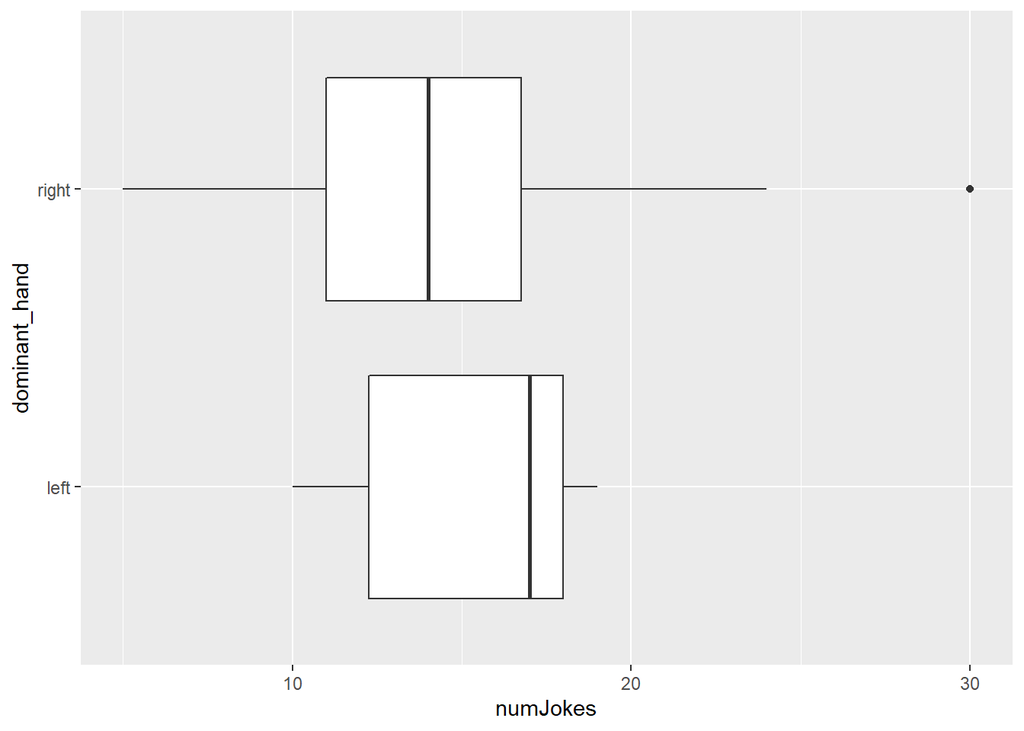

```r
ggplot(comdianAndNumCallbacks) +
  geom_boxplot(mapping = aes(x = numJokes, y = dominant_hand))
```

### Dominant Hand and Number of Swear Words

Does handedness affect the number of swear words?

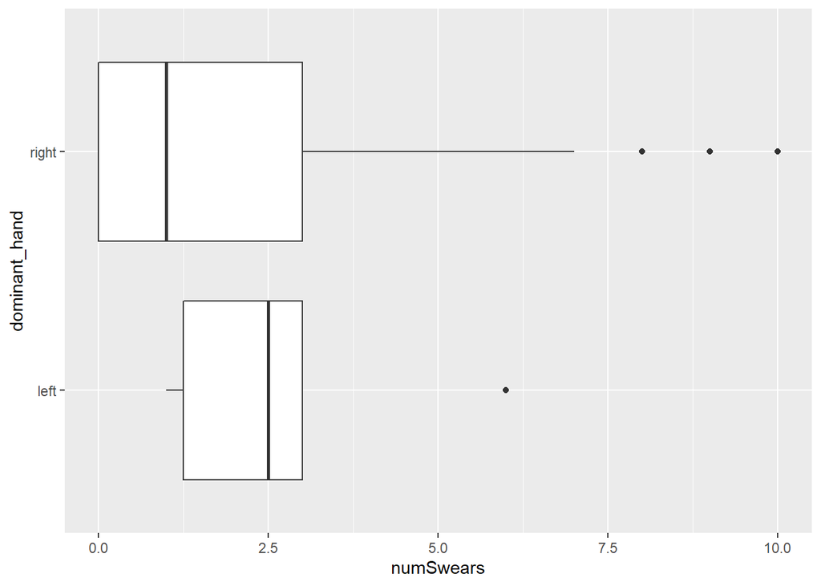

```r
ggplot(comedianAndNumberOfSwearWords) +
  geom_boxplot(mapping = aes(x = numSwears, y = dominant_hand))
```

### Dominant Hand and number of Callbacks

Does handedness affect the number of callbacks that a comedian uses?

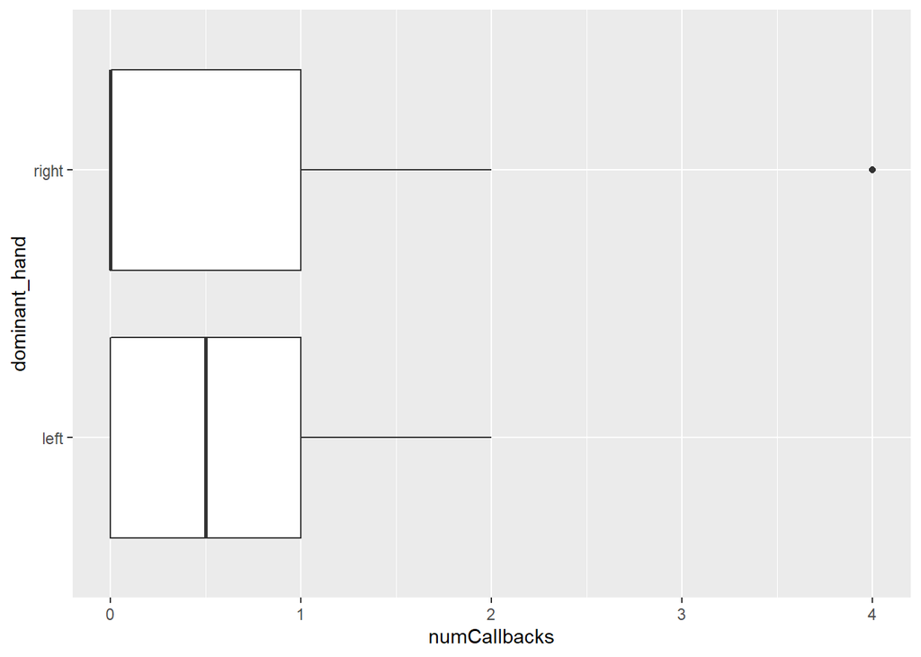

```r
ggplot(comdianAndNumCallbacks) +
  geom_boxplot(mapping = aes(x = numCallbacks, y = dominant_hand))
```

Interestingly, the upper and lower quartiles are almost identical, but the average number of callbacks are off by 0.5 in favor of lefties.

## Shirt Color

### Shirt Color by Comedian

What is the distribution of shirt color chosen by the comedians?

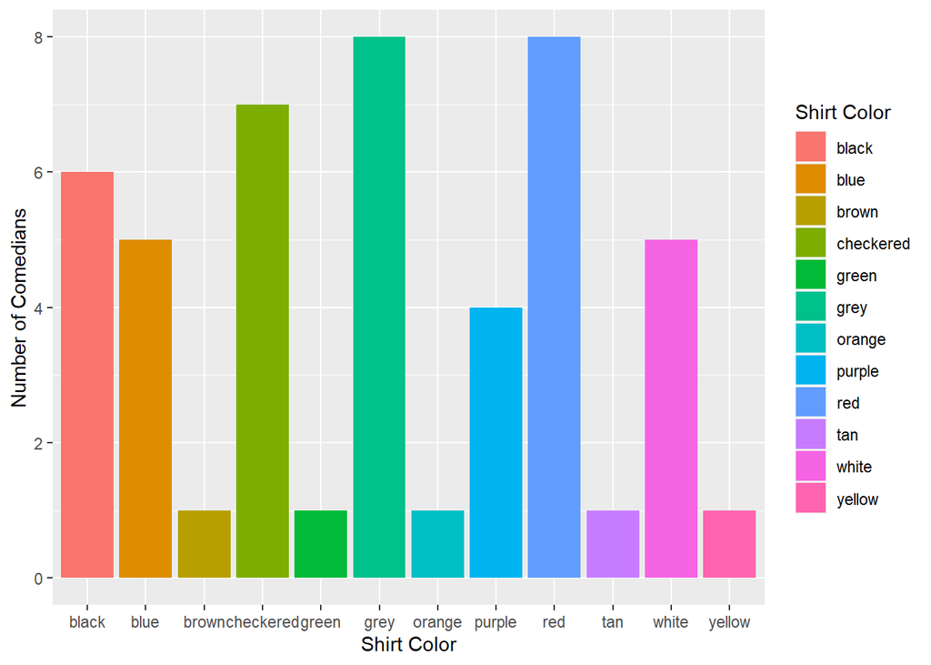

```r
ggplot(comedians) +
  geom_bar(mapping = aes(x = shirt_color, fill = shirt_color)) +
  labs(x = "Shirt Color", fill = "Shirt Color", y = "Number of Comedians")
```

### Shirt Color vs Crowd Response

How does shirt color affect the average crowd response?

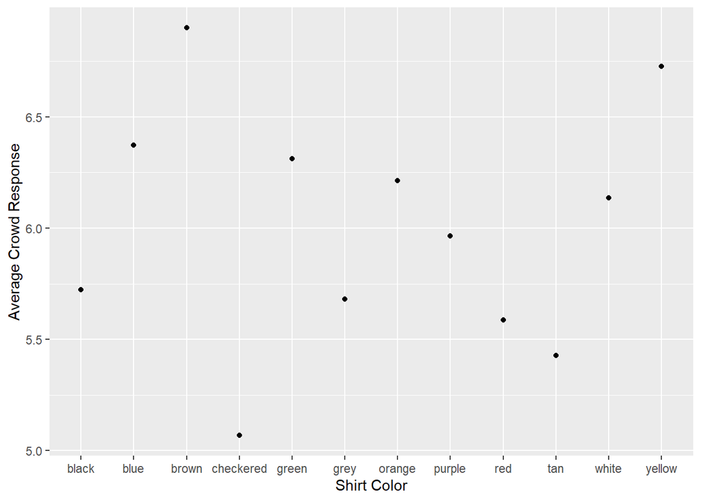

```r
ggplot(shirtColorVsAvgResp) +
  geom_point(mapping = aes(x = shirt_color, y = avgResponse)) +
  labs(x = "Shirt Color", y = "Average Crowd Response")
```

In our study, brown and yellow significantly outperform shirts of other colors, while checkered shirts perform worst on average.

## Sex vs. Average Crowd Response

How does the sex of our comedians affect the average crowd response?

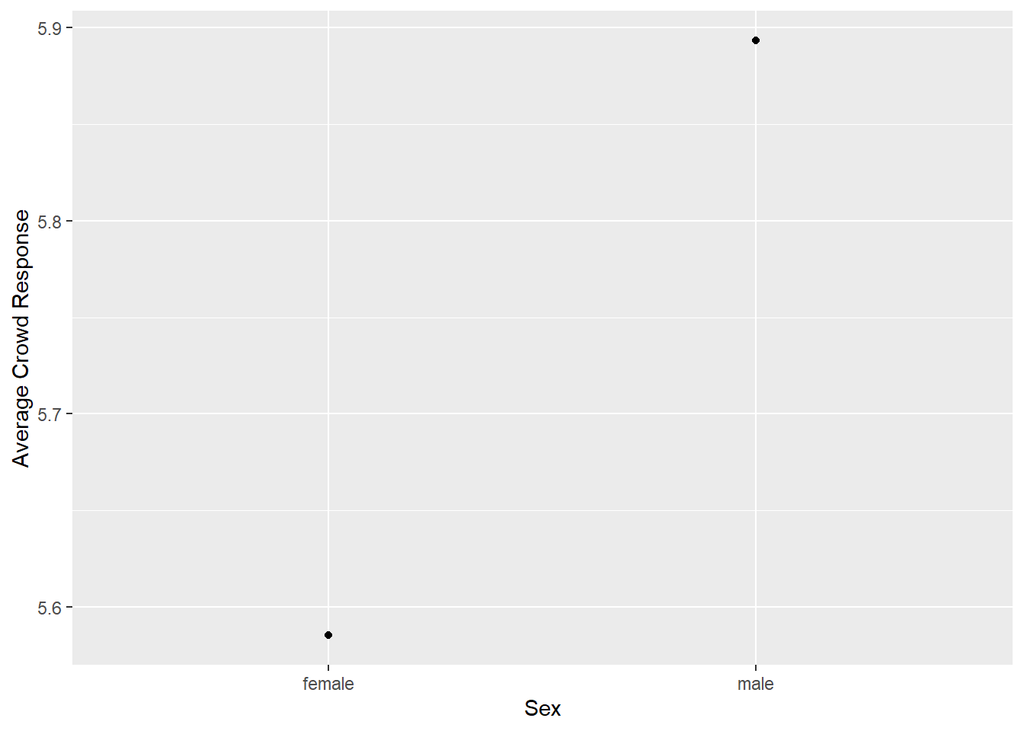

```r
ggplot(genderComedianAvgResponse) +
  geom_point(mapping = aes(x = sex, y = avgResponse)) +
  labs(x = "Sex", y = "Average Crowd Response")
```

The male participants in our study outperformed the females on average by ~0.3 in crowd reaction.